# 01-Introducción

Javier Cara

11 de septiembre de 2018

# 1 Qué es statistical learning?

Supongamos que somos consultores contratados por un cliente que quiere analizar como la publicidad mejora las ventas de un producto determinado.

```r
datos = read.csv("Advertising.csv")
str(datos)
```

```
## 'data.frame':    200 obs. of  5 variables:
##  $ X        : int  1 2 3 4 5 6 7 8 9 10 ...
##  $ TV       : num  230.1 44.5 17.2 151.5 180.8 ...
##  $ radio    : num  37.8 39.3 45.9 41.3 10.8 48.9 32.8 19.6 2.1 2.6 ...
##  $ newspaper: num  69.2 45.1 69.3 58.5 58.4 75 23.5 11.6 1 21.2 ...
##  $ sales    : num  22.1 10.4 9.3 18.5 12.9 7.2 11.8 13.2 4.8 10.6 ...
```

donde:

- sales: ventas del producto en 200 diferentes mercados (en miles de unidades).
- TV: presupuesto invertido en TV (en miles de dolares).
- radio: presupuesto invertido en radio (en miles de dolares).
- newspaper: presupuesto invertido en newspaper (en miles de dolares).

(datos tomados de http://www-bcf.usc.edu/~gareth/ISL/data.html)

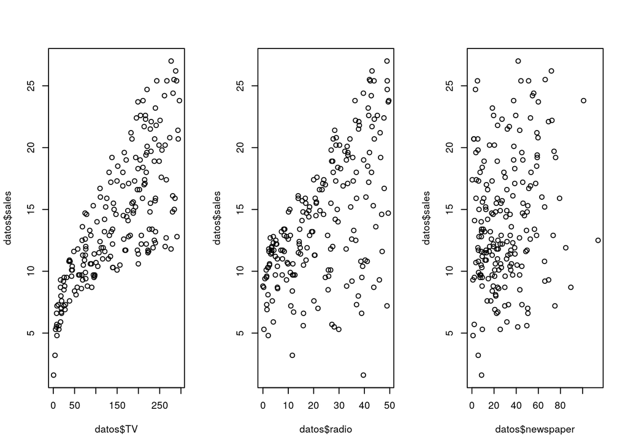

```r
par(mfrow=c(1,3))
plot(datos$TV, datos$sales)
plot(datos$radio, datos$sales)
plot(datos$newspaper, datos$sales)
```

Queremos encontrar la relación entre publicidad y ventas. Proponemos:

$Y = f(X) + \epsilon$

- Y: variable respuesta
- $X = (X_1,X_2,\ldots,X_p)$: regresores
- f: función que nos da la relación entre Y - X
- $\epsilon$: término de error. Se modela como una variable aleatoria independiente de $X$ y con media cero.

Por ejemplo:

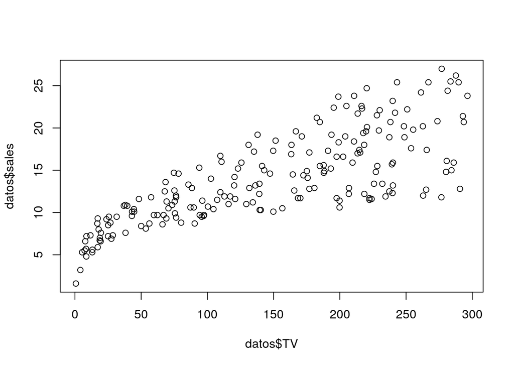

```r
plot(datos$TV, datos$sales)
```

```r
m1 = lm(sales ~ TV, data = datos)
print(m1)
```

```
##
## Call:
## lm(formula = sales ~ TV, data = datos)
##
## Coefficients:
## (Intercept)           TV
##     7.03259      0.04754
```

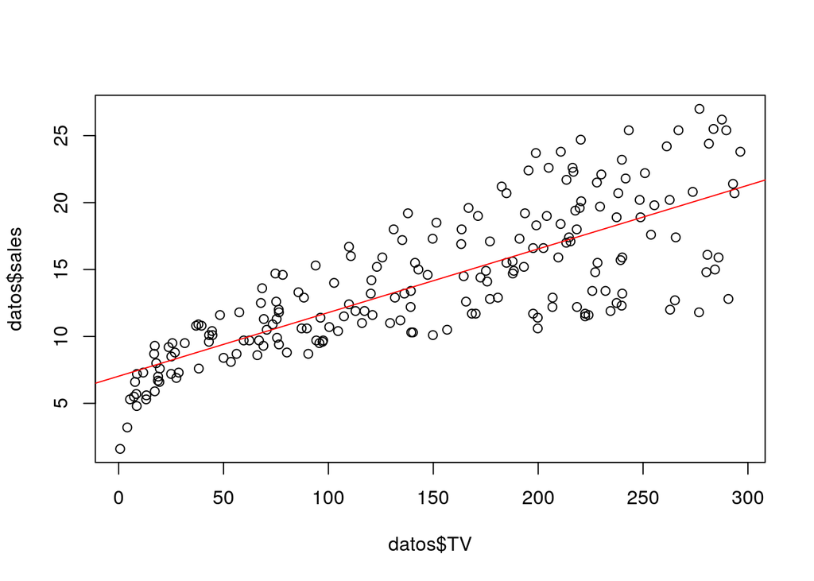

```r
plot(datos$TV, datos$sales)
abline(m1, col = "red", lwd = 1)
```

Como vemos:

- Y = sales
- X = TV
- f(X) = 7.0325 + 0.0475 * X
- $\epsilon$ : la diferencia entre la recta y los puntos

En esencia, *statistical learning* hace referencia al conjunto de herramientas para estimar $f$.

## 1.1 Por qué estimar f?

Hay dos razones principales por las que estamos interesados en estimar *f*:

### 1.1.1 Predicción

$\hat Y = \hat f(X)$

donde $\hat f$ refresenta la estimación de $f$.

El objetivo de la asignatura es estimar *f* de manera que minimicemos el error reducible.

### 1.1.2 Inferencia

Queremos entender la relación entre Y y X. En el ejemplo analizado:

- Que medio contribuye a las ventas?
- Cual es el que más contribuye?

## 1.2 Como estimamos f?

Dados unos datos, $(Y,X)$, queremos determinar la relación entre Y y X. Para ello usamos un modelo matemático del tipo:

$Y = f(X) + \epsilon$

### 1.2.1 Métodos paramétricos

La función $f(X)$ depende de una serie de parámetros. En el ejemplo anterior:

$Ventas = \beta_0 + \beta_1 * TV + \epsilon$

Este modelo depende de los parámetros $\beta_0, \beta_1$. El objetivo es determinar estos parámetros.

### 1.2.2 Métodos no paramétricos

Por ejemplo, árboles de regresión.